# INFSCI 2595 Spring 2023 Homework: 02

```r
### degree 8
viz_trend_8 <- predict(fit_lm_8,input_viz)

viz_trend_8
```

```
##           1           2           3           4           5           6
##  5.15148798  6.39834569  7.39819348  8.17945552  8.76821375  9.18834716
##           7           8           9          10          11          12
##  9.46166526  9.60803598  9.64550826  9.59042922  9.45755631  9.26016438
##          13          14          15          16          17          18
##  9.01014796  8.71811876  8.39349861  8.04460789  7.67874968  7.30228969
##          19          20          21          22          23          24
##  6.92073210  6.53879143  6.16046062  5.78907537  5.42737489  5.07755919
##          25          26          27          28          29          30
##  4.74134298  4.42000636  4.11444238  3.82520151  3.55253331  3.29642516
##          31          32          33          34          35          36
##  3.05663844  2.83274197  2.62414304  2.43011602  2.24982868  2.08236629
##          37          38          39          40          41          42
##  1.92675365  1.78197506  1.64699242  1.52076148  1.40224632  1.29043219
##          43          44          45          46          47          48
##  1.18433684  1.08302024  0.98559300  0.89122341  0.79914324  0.70865234
##          49          50          51          52          53          54
##  0.61912222  0.52999849  0.44080242  0.35113162  0.26065981  0.16913594
##          55          56          57          58          59          60
##  0.07638256 -0.01770641 -0.11316854 -0.20997617 -0.30804021 -0.40721429
##          61          62          63          64          65          66
## -0.50729935 -0.60804836 -0.70917145 -0.81034113 -0.91119771 -1.01135477
##          67          68          69          70          71          72
## -1.11040475 -1.20792454 -1.30348100 -1.39663651 -1.48695436 -1.57400399
##          73          74          75          76          77          78
## -1.65736617 -1.73663787 -1.81143701 -1.88140683 -1.94622017 -2.00558323
##          79          80          81          82          83          84
## -2.05923922 -2.10697149 -2.14860646 -2.18401598 -2.21311949 -2.23588567
##          85          86          87          88          89          90
## -2.25233365 -2.26253383 -2.26660830 -2.26473070 -2.25712578 -2.24406832
##          91          92          93          94          95          96
## -2.22588181 -2.20293646 -2.17564694 -2.14446952 -2.10989889 -2.07246446
##          97          98          99         100         101         102
## -2.03272622 -1.99127029 -1.94870391 -1.90565020 -1.86274238 -1.82061777
##         103         104         105         106         107         108
## -1.77991133 -1.74124903 -1.70524073 -1.67247296 -1.64350137 -1.61884295
##         109         110         111         112         113         114
## -1.59896812 -1.58429259 -1.57516918 -1.57187944 -1.57462534 -1.58352082
##         115         116         117         118         119         120
## -1.59858348 -1.61972625 -1.64674919 -1.67933149 -1.71702358 -1.75923962
```

[output cut: 13 more lines]

```
## 13.82045079 15.58176314 17.46182933 19.46218591 21.58376898 23.82684467
##         163         164         165         166         167         168
## 26.19093557 28.67474309 31.27606560 33.99171225 36.81741221 39.74771946
##         169         170         171         172         173         174
## 42.77591266 45.89389030 49.09206069 52.35922694 55.68246654 59.04700551
##         175         176         177         178         179         180
## 62.43608706 65.83083441 69.21010785 72.55035565 75.82545893 79.00657012
##         181         182         183         184         185         186
## 82.06194500 84.95676802 87.65297097 90.10904454 92.27984289 94.11638090
##         187         188         189         190         191         192
## 95.56562400 96.57027034 97.06852528 96.99386789 96.27480931 94.83464287
##         193         194         195         196         197         198
## 92.59118576 89.45651202 85.33667673 80.13143123 73.73392913 66.03042300
##         199         200         201
## 56.89995148 46.21401668 33.83625164
```

```r
### degree 9
viz_trend_9 <- predict(fit_lm_9,input_viz)

viz_trend_9
```

```
##            1            2            3            4            5            6
##   5.46318631   5.82566212   6.23567147   6.66922667   7.10619570   7.52992246
##            7            8            9           10           11           12
##   7.92687221   8.28630124   8.59994942   8.86175483   9.06758922   9.21501347
##           13           14           15           16           17           18
##   9.30305199   9.33198512   9.30315862   9.21880944   9.08190676   8.89600759
##           19           20           21           22           23           24
##   8.66512611   8.39361585   8.08606419   7.74719815   7.38180103   6.99463911
##           25           26           27           28           29           30
##   6.59039768   6.17362592   5.74868993   5.31973329   4.89064475   4.46503224
##           31           32           33           34           35           36
##   4.04620301   3.63714908   3.24053778   2.85870678   2.49366320   2.14708645
##           37           38           39           40           41           42
##   1.82033428   1.51445185   1.23018321   0.96798513   0.72804273   0.51028676
##           43           44           45           46           47           48
##   0.31441213   0.13989753  -0.01397423  -0.14809523  -0.26351125  -0.36140037
##           49           50           51           52           53           54
##  -0.44305163  -0.50984400  -0.56322568  -0.60469401  -0.63577601  -0.65800973
##           55           56           57           58           59           60
##  -0.67292657  -0.68203448  -0.68680243  -0.68864581  -0.68891329  -0.68887473
##           61           62           63           64           65           66
##  -0.68971058  -0.69250247  -0.69822525  -0.70774037  -0.72179060  -0.74099615
##           67           68           69           70           71           72
##  -0.76585210  -0.79672716  -0.83386374  -0.87737920  -0.92726844  -0.98340746
##           73           74           75           76           77           78
##  -1.04555821  -1.11337434  -1.18640795  -1.26411730  -1.34587523  -1.43097844
##           79           80           81           82           83           84
##  -1.51865733  -1.60808645  -1.69839543  -1.78868028  -1.87801502  -1.96546344
##           85           86           87           88           89           90
##  -2.05009103  -2.13097684  -2.20722532  -2.27797789  -2.34242426  -2.39981332
##           91           92           93           94           95           96
##  -2.44946358  -2.49077297  -2.52322803  -2.54641225  -2.56001358  -2.56383102
##           97           98           99          100          101          102
##  -2.55778013  -2.54189745  -2.51634375  -2.48140596  -2.43749788  -2.38515940
##          103          104          105          106          107          108
##  -2.32505433  -2.25796676  -2.18479583  -2.10654898  -2.02433358  -1.93934694
##          109          110          111          112          113          114
##  -1.85286471  -1.76622759  -1.68082645  -1.59808582  -1.51944576  -1.44634214
##          115          116          117          118          119          120
##  -1.38018548  -1.32233817  -1.27409042  -1.23663475  -1.21103932  -1.19822003
```

[output cut: 13 more lines]

```
##  17.15794803  20.17514560  23.49232582  27.12248400  31.07759175  35.36836815
##          163          164          165          166          167          168
##  40.00403105  44.99202743  50.33774185  56.04418187  62.11163942  68.53732685
##          169          170          171          172          173          174
##  75.31498666  82.43447365  89.88130825  97.63619982 105.67453862 113.96585508
##          175          176          177          178          179          180
## 122.47324517 131.15276031 139.95276049 148.81322915 157.66504834 166.42923259
##          181          182          183          184          185          186
## 175.01611999 183.32451880 191.24080815 198.63799090 205.37469718 211.29413675
##          187          188          189          190          191          192
## 216.22299849 219.97029509 222.32615118 223.06053302 221.92191772 218.63590009
##          193          194          195          196          197          198
## 212.90373514 204.40081409 192.77507188 177.64532397 158.59953034 135.19298439
##          199          200          201
## 106.94642460  73.34406645  33.83155252
```

### 2c)

Let’s manipulate the data before visualizing the predictions. This way we can organize the data into a “tidy format” to support proper visualization strategies.

The code chunk below is started for you. The `input_viz` object is piped into the `mutate()` function where two data variables are assigned, `pred_trend` and `poly_degree`. The predictions made in the previous question will be assigned to the `pred_trend` data variable. You will manually assign the `poly_degree` variable for the model which made the predictions. Please note that you only need to provide a scalar value for `poly_degree`. The `mutate()` function will make sure to broadcast that scalar value to all rows in the tibble.

Let’s start by compiling the `df_viz_1` object which stores the prediction input and predicted trend for the linear relationship model.

**Complete the code chunk below by assigning the linear relationship model’s predicted trend to the `pred_trend` data variable and assign the value `1` to the `poly_degree` data variable. The `df_viz_1` object is assigned for you and a glimpse is displayed to the screen. If you created the `df_viz_1` object correctly it should consist of 3 variable (columns) and 201 rows.**

#### SOLUTION

```r
df_viz_1 <- input_viz %>%
  mutate(pred_trend = viz_trend_1,
         poly_degree = 1)

df_viz_1 %>% glimpse()
```

```
## Rows: 201
## Columns: 3
## $ x           <dbl> -2.342417, -2.317484, -2.292550, -2.267616, -2.242682, -2.…
## $ pred_trend  <dbl> 0.4700900, 0.4786779, 0.4872658, 0.4958537, 0.5044415, 0.5…
## $ poly_degree <dbl> 1, 1, 1, 1, 1, 1, 1, 1, 1, 1, 1, 1, 1, 1, 1, 1, 1, 1, 1, 1…
```

### 2d)

You can now visualize the predicted trend for the linear relationship! You will use a line to visualize the trend so that way the smooth sequential trend is visualized.

**Pass the `df_viz_1` tibble into `ggplot()`. Map the `x` aesthetic to the `x` variable within the “parent” `ggplot()` call. Add the `geom_line()` layer and map the `y` aesthetic to the `pred_trend` variable within the `geom_line()` geom. Thus, you should NOT map both `x` and `y` aesthetics in the “parent” `ggplot()` call.**

#### SOLUTION

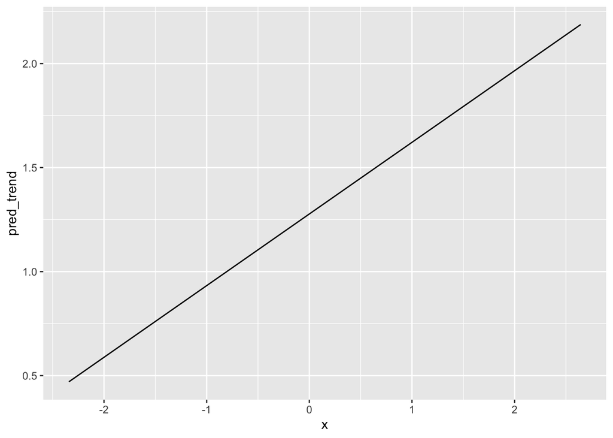

```r
### add your code here
df_viz_1 %>%
  ggplot(mapping = aes(x=x)) +
  geom_line(mapping = aes(y=pred_trend))
```

### 2e)

Let’s add further context to the predictive trend visualization by overlaying the original training set scatter plot. We thus need to create a graphic that uses two different data sets. This is ok! Each `geom_*` function has a `data` argument. By default, the `geom_*` function, (such as `geom_point()` or `geom_line()`) inherits the `data` provided to the “parent” `ggplot()` call. However, we can override this behavior by manually specifying a new data set to the `data` argument within the `geom_*` layer! This effectively allows us to show behavior coming from multiple data sets.

**Visualize the predicted trend associated with the linear relationship again. Pass the `df_viz_1` tibble into `ggplot()`. Map the `x` aesthetic to the `x` variable within the “parent” `ggplot()` call. However, before adding `geom_line()` add `geom_point()` where you specify the `data` argument in `geom_point()` to be `df_low_high`. Map the `y` aesthetic within `geom_point()` to the `y` variable and manually assign the marker `shape` to 0 and the marker `color` to `'red'`. Add the `geom_line()` layer where you map the `y` aesthetic to the `pred_trend` variable and manually assign the line `size` to 1.**

Your completed graphic should display the original training set as red open squares and the predicted trend as a black line.

#### SOLUTION

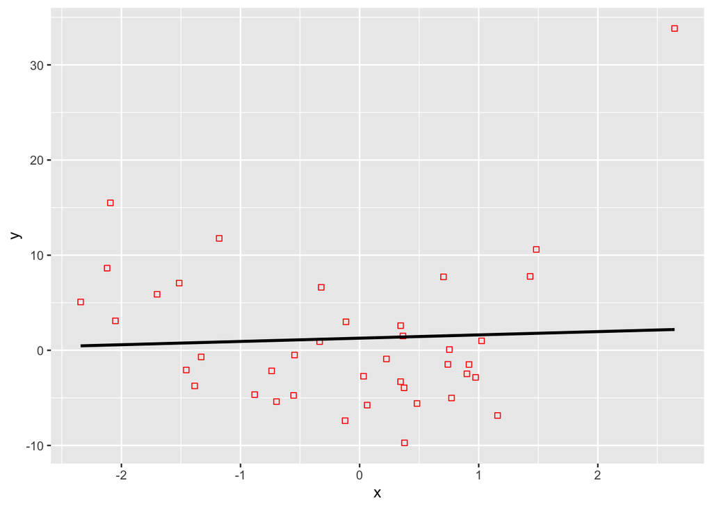

```r
### add your code here
df_viz_1 %>%
  ggplot(mapping = aes(x=x)) +
  geom_point(mapping = aes(y = y), shape = 0, color = 'red',data = df_low_high) +
  geom_line(mapping = aes(y = pred_trend), size = 1)
```

### 2f)

You visualized the predicted trend associated with 1 model! You must now repeat these steps for the remaining 8 models. You will start by properly organizing the predictive trends from the other 8 models into their own tibbles.

**Complete the code chunks below. You must assign the predictive trends to the `pred_trend` data variable and assign the correct value for the `poly_degree` data variable. The comments and variable names state the models associated with each code chunk.**

**NOTE**: This is NOT the most efficient way to properly organize the predictions. More streamlined approaches make use of **functional programming** techniques to create one properly organized and “tidy” data set in just a few lines of code. We will learn how to do that later in the semester. For now though, we will go through the tedious way!

#### SOLUTION

```r
### quadratic relationship (degree 2)
df_viz_2 <- input_viz %>%
  mutate(pred_trend = viz_trend_2,
         poly_degree = 2)


df_viz_2
```

```
## # A tibble: 201 × 3
##        x pred_trend poly_degree
##    <dbl>      <dbl>       <dbl>
##  1 -2.34      12.6            2
##  2 -2.32      12.3            2
##  3 -2.29      11.9            2
##  4 -2.27      11.5            2
##  5 -2.24      11.1            2
##  6 -2.22      10.8            2
##  7 -2.19      10.4            2
##  8 -2.17      10.0            2
##  9 -2.14       9.68           2
## 10 -2.12       9.33           2
## # … with 191 more rows
```

```r
### cubic relationship (degree 3)
df_viz_3 <- input_viz %>%
  mutate(pred_trend = viz_trend_3,
         poly_degree = 3)

df_viz_3
```

```
## # A tibble: 201 × 3
##        x pred_trend poly_degree
##    <dbl>      <dbl>       <dbl>
##  1 -2.34       8.27           3
##  2 -2.32       8.16           3
##  3 -2.29       8.04           3
##  4 -2.27       7.93           3
##  5 -2.24       7.81           3
##  6 -2.22       7.69           3
##  7 -2.19       7.56           3
##  8 -2.17       7.44           3
##  9 -2.14       7.31           3
## 10 -2.12       7.18           3
## # … with 191 more rows
```

```r
### degree 4
df_viz_4 <- input_viz %>%
  mutate(pred_trend = viz_trend_4,
         poly_degree = 4)

df_viz_4
```

```
## # A tibble: 201 × 3
##        x pred_trend poly_degree
##    <dbl>      <dbl>       <dbl>
##  1 -2.34       8.84           4
##  2 -2.32       8.67           4
##  3 -2.29       8.49           4
##  4 -2.27       8.32           4
##  5 -2.24       8.14           4
##  6 -2.22       7.97           4
##  7 -2.19       7.79           4
##  8 -2.17       7.62           4
##  9 -2.14       7.45           4
## 10 -2.12       7.27           4
## # … with 191 more rows
```

```r
### degree 5
df_viz_5 <- input_viz %>%
  mutate(pred_trend = viz_trend_5,
         poly_degree = 5)

df_viz_5
```

```
## # A tibble: 201 × 3
##        x pred_trend poly_degree
##    <dbl>      <dbl>       <dbl>
##  1 -2.34       8.84           5
##  2 -2.32       8.67           5
##  3 -2.29       8.49           5
##  4 -2.27       8.32           5
##  5 -2.24       8.14           5
##  6 -2.22       7.97           5
##  7 -2.19       7.79           5
##  8 -2.17       7.62           5
##  9 -2.14       7.45           5
## 10 -2.12       7.27           5
## # … with 191 more rows
```

```r
### degree 6
df_viz_6 <- input_viz %>%
  mutate(pred_trend = viz_trend_6,
         poly_degree = 6)
```

```r
### degree 7
df_viz_7 <- input_viz %>%
  mutate(pred_trend = viz_trend_7,
         poly_degree = 7)
```

```r
### degree 8
df_viz_8 <- input_viz %>%
  mutate(pred_trend = viz_trend_8,
         poly_degree = 8)
```

```r
### degree 9
df_viz_9 <- input_viz %>%
  mutate(pred_trend = viz_trend_9,
         poly_degree = 9)
```

### 2g)

Do not worry, you will not create separate plots for each model’s predictions! Instead, you will concatenate the 9 tibbles together into a single tibble! You will “stack” the tibbles vertically by *binding the rows* together. This operation works because all 9 `df_viz_*` objects have the same columns! A little planning goes a long way!

You can vertically concatenate or bind rows via the `bind_rows()` function from `dplyr`. You must provide all data.frames (tibbles) you wish to bind together as arguments to `bind_rows()`. Each data set (argument to the function) must be separated by a comma, `,`. You do **not** need to worry about the `.id` argument to `bind_rows()` for this current operation.

**The code chunk below creates a variable `df_viz_all`. You must use the `bind_rows()` function to bind or stack together all 9 visualization tibbles.**

*HINT*: If you created the `df_viz_all` object correctly, it should consist of 1809 rows and 3 columns.

#### SOLUTION

```r
df_viz_all <- bind_rows(df_viz_1,df_viz_2,df_viz_3,df_viz_4,df_viz_5,df_viz_6,df_viz_7,df_viz_8,df_viz_9)
df_viz_all
```

```
## # A tibble: 1,809 × 3
##        x pred_trend poly_degree
##    <dbl>      <dbl>       <dbl>
##  1 -2.34      0.470           1
##  2 -2.32      0.479           1
##  3 -2.29      0.487           1
##  4 -2.27      0.496           1
##  5 -2.24      0.504           1
##  6 -2.22      0.513           1
##  7 -2.19      0.522           1
##  8 -2.17      0.530           1
##  9 -2.14      0.539           1
## 10 -2.12      0.547           1
## # … with 1,799 more rows
```

### 2h)

The `df_viz_all` is tidy. A column (variable) exists for each attribute associated with the data. A variable exists for the input, `x`, a variable exists for the predicted trend, `pred_trend`, and an identifier exists which identifies which model made the predictions, `poly_degree`. You will now use all variables to create a faceted figure showing the predictions associated with each model.

**Pipe the `df_viz_all` object to `ggplot()` and map the `x` aesthetic to the `x` variable within the “parent” `ggplot()` call. Add the `geom_line()` layer and map the `y` aesthetic to the `pred_trend` variable within `geom_line()`. Add the facets via the `facet_wrap()` function. The facets must be a function of the `poly_degree` variable.**

#### SOLUTION

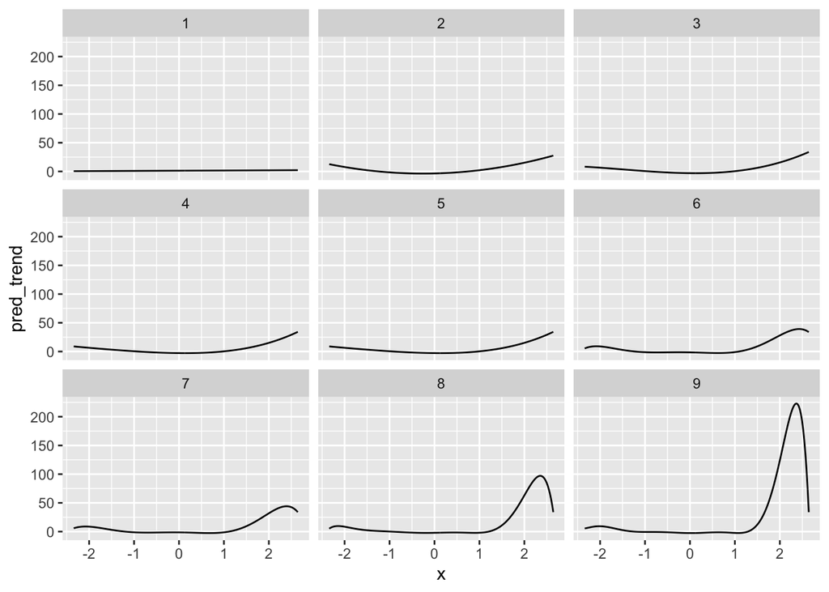

```r
### add your code here
df_viz_all %>%
  ggplot(mapping = aes(x=x)) +
  geom_line(mapping = aes(y = pred_trend)) +
  facet_wrap('poly_degree')
```

### 2i)

It might be difficult to see what’s going on within each facet. Let’s “zoom” the y-axis within each facet to give a better picture of the trend associated with each model.

**Repeat the visualization from the previous problem, but this time set `scales = 'free_y'` within the `facet_wrap()` function.**

#### SOLUTION

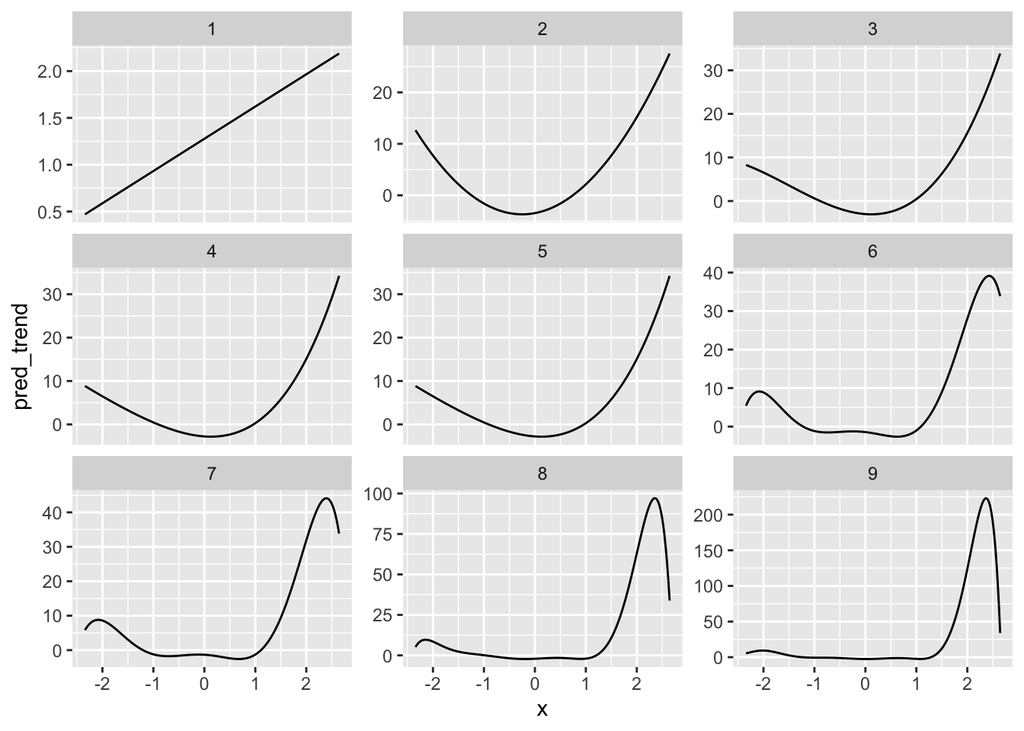

```r
### add your code here

df_viz_all %>%
  ggplot(mapping = aes(x=x)) +
  geom_line(mapping = aes(y = pred_trend)) +
  facet_wrap(~poly_degree, scales = 'free_y')
```

### 2j)

Lastly, let’s overlay the training set for additional context within each facet. To do so, you must override the `data` argument within the additional `geom_point()` layer, just as you did in Problem 2e).

**Repeat the visualization from the previous problem, however this time include `geom_point()` in between the “parent” `ggplot()` call and the `geom_line()` layer. You must override the `data` argument within this `geom_point()` layer by assigning `data` to `df_low_high`. You must map the `y` aesthetic directly within `geom_point()` to the `y` variable. Manually specify the marker `shape` to be `0` and the marker `color` to be `'red'` within `geom_point()`.**

#### SOLUTION

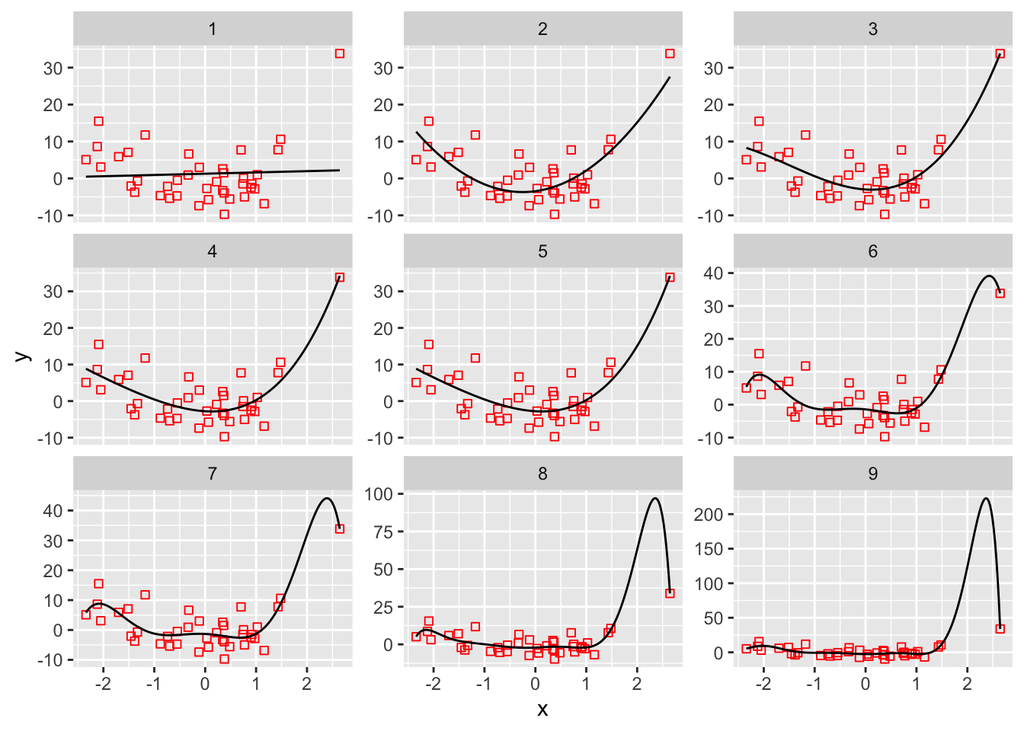

```r
### add your code here
df_viz_all %>%
  ggplot(mapping = aes(x=x)) +
  geom_point(mapping = aes(y=y),shape = 0, color = 'red',data = df_low_high) +
  geom_line(mapping = aes(y = pred_trend)) +
  facet_wrap("poly_degree",scales = "free_y")
```

### 2k)

**You previously used two performance metrics to identify the best model. How would you describe the predictive trends associated with the best performing model? Do the trends seem consistent with the training set?**

#### SOLUTION

**Although the prediction models 7, 8, and 9 appear to overlap with the data the most, they overlap too much with the monitoring data and suffer from over-fitting problems. This resulted in several models with poor generalization capabilities that are not applicable to predict other data.**

## Problem 03

You previously selected the best model based on the **training set** alone. Your selection therefore did not consider how well the model will perform on new data! You will now try to identify the best model in hopes of finding one that *generalizes* to new data.

You will begin by creating a single training/test split. Sometimes this procedure is referred to as a training/validation split, but the motivation and goals are the same. You will randomly partition the data into a dedicated training set and dedicated hold-out set. You will train the models on the training set, and assess their performance on the hold-out set.

### 3a)

You will use an 80/20 train/test split. Thus, 80% of the data will be used for training the models and 20% of the data will be used to test the models. You will use the base R `sample()` function to create the vector of row indices that will serve as the training set.

The random seed is specified for you with the `set.seed()` function in the code chunk below. This ensures that the data splitting is **reproducible**. You will therefore get the same split every time you run the code chunk below. Please note, you must run the entire code chunk to ensure reproducibility.

**Complete the code chunk below. Use the `sample()` function to randomly sample 80% of the rows from the `df_low_high` data set. The `sample()` function randomly selects elements from a provided vector. You must therefore provide a vector that starts at 1 and ends at the number of rows in `df_low_high`. The result of `sample()` must be assigned to the `id_train` variable.**

**You must then use `id_train` to slice the training set from `df_low_high` and slice all except the `id_train` indices to create the hold-out test set. The training set is `df_train` and the hold-out test set is `df_holdout` in the code chunk below.**

#### SOLUTION

```r
set.seed(202214)
id_train <- sample(1:nrow(df_low_high),32)

df_train <- df_low_high %>% slice(id_train)
df_holdout <- df_low_high %>% slice(-id_train)

df_train
```

```
## # A tibble: 32 × 2
##          x       y
##      <dbl>   <dbl>
##  1 -0.122  -7.40
##  2  0.344   2.59
##  3  1.48   10.6
##  4 -2.05    3.09
##  5 -2.34    5.08
##  6 -1.70    5.89
##  7 -1.52    7.07
##  8 -1.39   -3.74
##  9  0.0633 -5.76
## 10  0.754   0.0799
## # … with 22 more rows
```

```r
df_holdout
```

```
## # A tibble: 8 × 2
##        x     y
##    <dbl> <dbl>
## 1 -0.115  3.00
## 2  0.374 -3.94
## 3  0.704  7.72
## 4  0.772 -5.01
## 5  0.364  1.51
## 6 -1.46  -2.07
## 7  2.64  33.8
## 8 -0.322  6.62
```

### 3b)

Let’s visualize the data split so we know which observations were selected for training and which observations were selected for testing.

**Create a scatter plot using `ggplot2` which visualizes the relationship between the output `y` and the input `x`. You must use the marker color and marker shape to denote the training set from the hold-out test set.**

**There are multiple ways this figure can be created. It is up to you to make it, but you must create the figure using `ggplot2`. Use this as an opportunity to test out your understanding of the elements of the `ggplot2` philosophy for creating statistical visualizations.**

#### SOLUTION

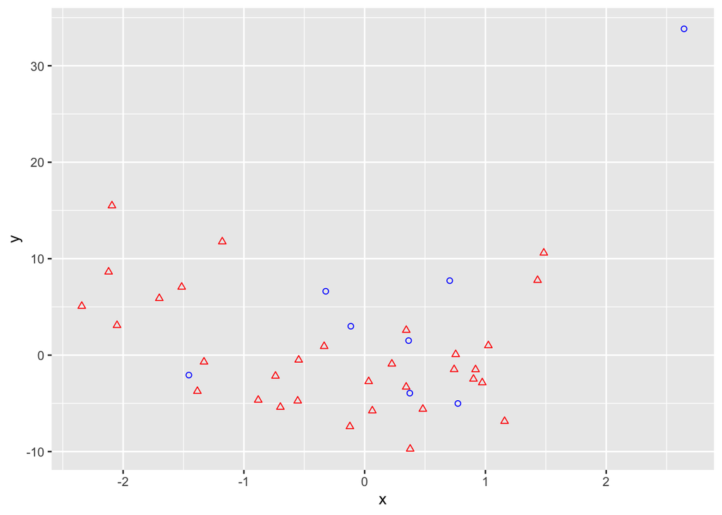

```r
### add your code here
df_low_high %>%
  ggplot(mapping = aes(x=x)) +
  geom_point(mapping = aes(y=y), shape = 2,color = 'red', data = df_train) +
  geom_point(mapping = aes(y=y), shape = 1,color = 'blue', data = df_holdout)
```

### 3c)

You will now fit the 9 polynomials using the training split. You **must NOT** use the complete original data set. You must fit the models using the randomly generated training split.

**You must use the `lm()` function, type in the correct formula, and assign the correct data set to the `data` argument of the `lm()` function. Again, this is tedious for now, but it is a learning experience!**

**The comments and variable names state which model should be specified in each code chunk.**

#### SOLUTION

```r
### linear relationship (degree 1)
fit_train_1 <- lm(y ~ x, data = df_train)

fit_train_1
```

```
##
## Call:
## lm(formula = y ~ x, data = df_train)
##
## Coefficients:
## (Intercept)            x
##     -0.2641      -1.9210
```

```r
### quadratic relationship (degree 2)
fit_train_2 <-lm(y ~ x + I(x^2), data = df_train)

fit_train_2
```

```
##
## Call:
## lm(formula = y ~ x + I(x^2), data = df_train)
##
## Coefficients:
## (Intercept)            x       I(x^2)
##     -3.6401       0.6271       3.0492
```

```r
### cubic relationship (degree 3)
fit_train_3 <-lm(y ~ x + I(x^2) + I(x^3), data = df_train)

fit_train_3
```

```
##
## Call:
## lm(formula = y ~ x + I(x^2) + I(x^3), data = df_train)
##
## Coefficients:
## (Intercept)            x       I(x^2)       I(x^3)
##      -4.527       -1.672        4.601        1.267
```

```r
### degree 4
fit_train_4 <-lm(y ~ x + I(x^2) + I(x^3) + I(x^4), data = df_train)

fit_train_4
```

```
##
## Call:
## lm(formula = y ~ x + I(x^2) + I(x^3) + I(x^4), data = df_train)
##
## Coefficients:
## (Intercept)            x       I(x^2)       I(x^3)       I(x^4)
##     -4.4066      -1.9498       4.2820       1.4664       0.1293
```

```r
### degree 5
fit_train_5 <-lm(y ~ x + I(x^2) + I(x^3) + I(x^4) + I(x^5), data = df_train)

fit_train_5
```

```
##
## Call:
## lm(formula = y ~ x + I(x^2) + I(x^3) + I(x^4) + I(x^5), data = df_train)
##
## Coefficients:
## (Intercept)            x       I(x^2)       I(x^3)       I(x^4)       I(x^5)
##    -3.22294      0.08626     -0.59483     -1.69332      2.32700      1.12799
```

```r
### degree 6
fit_train_6 <-lm(y ~ x + I(x^2) + I(x^3) + I(x^4) + I(x^5) + I(x^6), data = df_train)


fit_train_6
```

```
##
## Call:
## lm(formula = y ~ x + I(x^2) + I(x^3) + I(x^4) + I(x^5) + I(x^6),
##     data = df_train)
##
## Coefficients:
## (Intercept)            x       I(x^2)       I(x^3)       I(x^4)       I(x^5)
##    -3.32492      1.31739     -0.03174     -3.88739      1.51126      1.87140
##      I(x^6)
##     0.29893
```

```r
### degree 7
fit_train_7 <-lm(y ~ x + I(x^2) + I(x^3) + I(x^4) + I(x^5) + I(x^6) + I(x^7), data = df_train)

fit_train_7
```

```
##
## Call:
## lm(formula = y ~ x + I(x^2) + I(x^3) + I(x^4) + I(x^5) + I(x^6) +
##     I(x^7), data = df_train)
##
## Coefficients:
## (Intercept)            x       I(x^2)       I(x^3)       I(x^4)       I(x^5)
##     -4.5145       2.5107       9.1462      -5.1702      -9.2611       0.2738
##      I(x^6)       I(x^7)
##      3.4202       0.9505
```

```r
### degree 8
fit_train_8 <- lm(y ~ x + I(x^2)+ I(x^3) + I(x^4) + I(x^5) + I(x^6) + I(x^7) + I(x^8), data = df_train)

fit_train_8
```

```
##
## Call:
## lm(formula = y ~ x + I(x^2) + I(x^3) + I(x^4) + I(x^5) + I(x^6) +
##     I(x^7) + I(x^8), data = df_train)
##
## Coefficients:
## (Intercept)            x       I(x^2)       I(x^3)       I(x^4)       I(x^5)
##     -4.5050       1.4589       9.5391      -1.3436      -9.5915      -3.1944
##      I(x^6)       I(x^7)       I(x^8)
##      2.9423       1.8408       0.2576
```

```r
### degree 9
fit_train_9 <- lm(y ~ x + I(x^2) + I(x^3) + I(x^4) + I(x^5) + I(x^6) + I(x^7) + I(x^8) + I(x^9), data = df_train)

fit_train_9
```

```
##
## Call:
## lm(formula = y ~ x + I(x^2) + I(x^3) + I(x^4) + I(x^5) + I(x^6) +
##     I(x^7) + I(x^8) + I(x^9), data = df_train)
##
## Coefficients:
## (Intercept)            x       I(x^2)       I(x^3)       I(x^4)       I(x^5)
##     -3.6809      -0.4042       0.1165       4.7807      10.3328      -6.7692
##      I(x^6)       I(x^7)       I(x^8)       I(x^9)
##    -11.3657       0.4932       3.5204       0.8677
```

### 3d)

You fit 9 models on the training split, it is now time to assess their performance on the dedicated **hold-out** test split! You are therefore evaluating the models on data **not** used for estimating their coefficients!

**Calculate the hold-out set RMSE for each model. It is up to you as to how to organize the RMSE values and display the results. Bare minimum, you must display the RMSE for each model. You are only allowed to use functions from lecture.**

#### SOLUTION

```r
### add as many code chunks as you feel are necessary
modelr::rmse(fit_train_1,df_holdout)
```

```
## [1] 14.64953
```

```r
modelr::rmse(fit_train_2,df_holdout)
```

```
## [1] 7.877605
```

```r
modelr::rmse(fit_train_3,df_holdout)
```

```
## [1] 7.994202
```

```r
modelr::rmse(fit_train_4,df_holdout)
```

```
## [1] 9.623962
```

```r
modelr::rmse(fit_train_5,df_holdout)
```

```
## [1] 66.52861
```

```r
modelr::rmse(fit_train_6,df_holdout)
```

```
## [1] 110.5928
```

```r
modelr::rmse(fit_train_7,df_holdout)
```

```
## [1] 547.3029
```

```r
modelr::rmse(fit_train_8,df_holdout)
```

```
## [1] 852.5923
```

```r
modelr::rmse(fit_train_9,df_holdout)
```

```
## [1] 3585.753
```

### 3e)

**Which model is the best according to the hold-out evaluation? Is it the same model as identified from the training set performance? How does the hold-out set rank the model identified as the best according to the training set?**

#### SOLUTION

**The RMSE calculated from the hold-out evaluation shows that model 2 is the best. This is inconsistent with the results obtained from the previous training set, where the ninth model was the best. Here the dataset is randomly sampled and fitted with hold-out data after the prediction model is obtained using the training set.**

### 3f)

The models named `fit_lm_*` were trained on the entire data set, while the models named `fit_train_*` were trained on the random training split. Although the training sizes are different, let’s try to get some idea on the sensitivity of the coefficients to the data.

You must use the `coefplot::multiplot()` function to compare the coefficients based on the original data and based on the training split data. You will compare the same model, but the data used for estimating the coefficients are different.

**Compare the coefficient summaries using `coefplot::multiplot()` for the model that was considered to be the best based on the training set.**

**How do the coefficients compare between the two slightly different training sets?**

#### SOLUTION

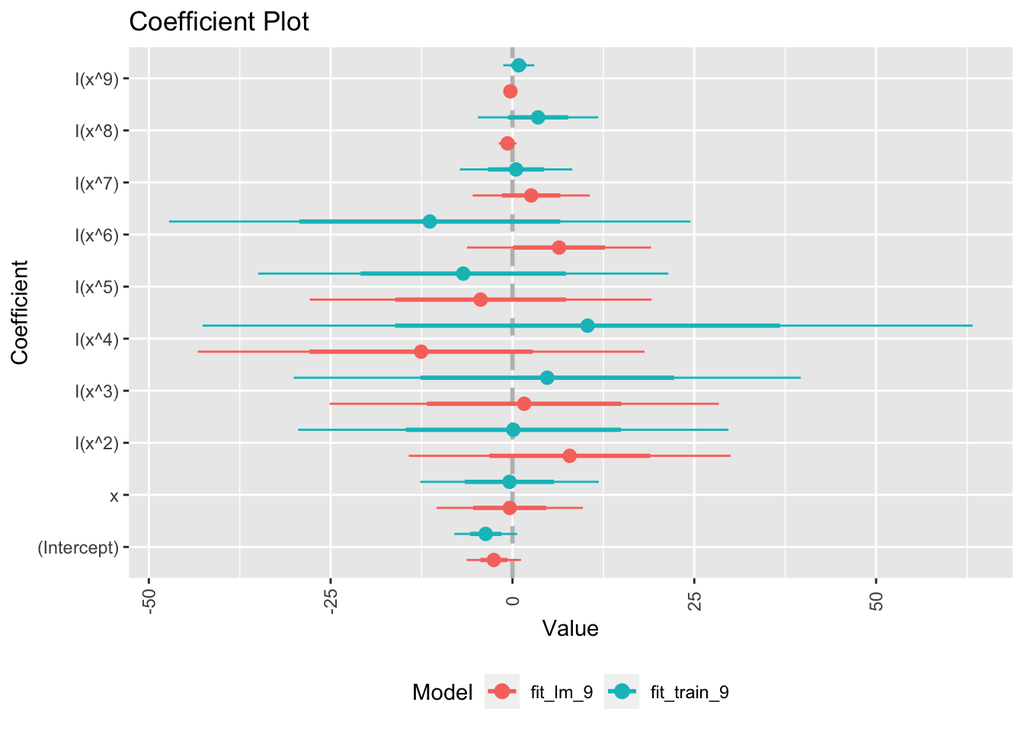

```r
### add your code here
coefplot::multiplot(fit_lm_9,fit_train_9)
```

**For the coefficients, neither model is significant since both models have more intersections of the data lines with 0.**

### 3g)

**Compare the coefficient summaries using `coefplot::multiplot()` for the model that was considered to be the best based on the train/test split evaluation.**

**How do the coefficients compare between the two slightly different training sets?**

#### SOLUTION

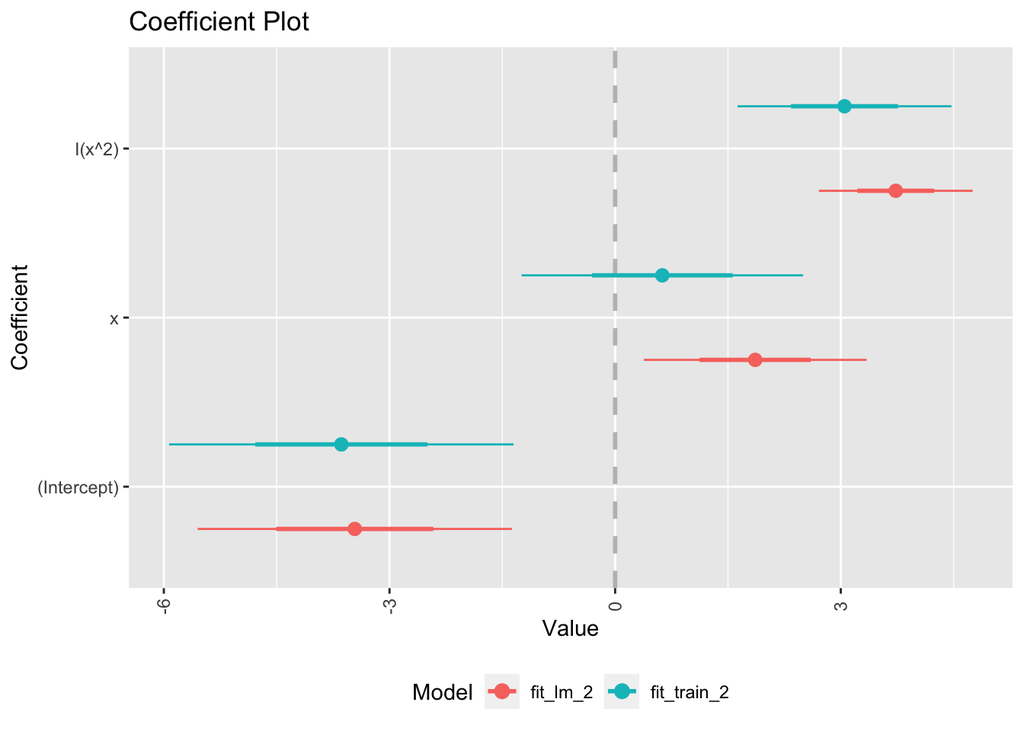

```r
### add your code here
coefplot::multiplot(fit_lm_2,fit_train_2)
```

**The coefficients of model 2 are more meaningful except that the same uncertainty variation pattern appears as in model 9. Most of whole lines of model 2 are in the negative or positive interval, with fewer cross sections.**

## Problem 04

You have fit the 9 polynomials and assessed their performance multiple ways. It’s time to now use **resampling** to understand the reliability of your performance assessments. You will specifically use the `caret` package to manage all aspects of data splitting, training, and evaluating the models. If you do not have the `caret` package downloaded and installed please do so before proceeding. You only need to download and install `caret` once.

### 4a)

**Load the `caret` library into the environment with the `library()` function.**

#### SOLUTION

```r
### add your code here
library(caret)
```

### 4b)

The resampling scheme is specified by the `trainControl()` function in `caret`. The type of scheme is controlled by the `method` argument. For k-fold cross-validation, the `method` argument must equal `'cv'` and the number of folds is controlled by the `number` argument. We could instruct `caret` to use repeated cross-validation by specifying `method` to be `'repeatedcv'` and including the number of repeats via the `repeates` argument. However, we will follow the process consistent with lecture and use 5-fold cross-validation for this assignment.

**Specify the resampling scheme by completing the code chunk below. Assign the result of the `trainControl()` function to the `my_ctrl` variable.**

**How many times will a model be trained and tested using the desired resampling scheme?**

#### SOLUTION

```r
my_ctrl <- trainControl(method = "cv",number = 5, savePredictions = TRUE)

my_ctrl
```

[output not shown]

[output cut: 60 more lines]

[output not shown]

How many times will an individual model be trained and tested?  
**A total of 5 times will be performed**

### 4c)

The `caret` package requires that we specify a primary performance metric of interest, even though it will calculate several performance metrics for us. Please remember that the response is a continuous variable.

**You must select a primary performance metric to use to compare the models. Specify an appropriate metric to use for this modeling task. Choices must be written as a string and assigned to the `my_metric` variable. Possible choices are “Accuracy”, “RMSE”, “Kappa”, “Rsquared”, “MAE”, “ROC”. Why did you make the the choice that you did?**

*NOTE*: Not all of the listed performance metrics above are relevant to regression problems!

```r
my_metric <- "RMSE"
```

**The response in this experiment is continuous, so we can only choose from “RMSE”, “Rsquared”, and “MAE” methods. is more responsive to the error of the data than MAE and Rsquared, and better reflects the discrete nature and accuracy of the model.**

### 4d)

You will now go through training and evaluating the 9 polynomial models with the `train()` function from `caret`. You will use the formula interface to specify the model relationship. You must fit a linear (first order polynomial), quadratic (second order polynomial), cubic (third order polynomial), and so on up to and including a 9th order polynomial just as you did before. The difference is that you are not calling the `lm()` function directly. Instead, the `caret` package will manage the fitting process for you.

Please note that you will use the entire data set for training and evaluating with resampling. The `caret` package will manage the data splitting for you.

**You must specify the `method` argument in the `train()` function to be `"lm"`. You must specify the `metric` argument to be `my_metric` that you selected in Problem 4c). You must specify the `trControl` argument to be `my_ctrl` that you specified in Problem 4b). Don’t forget to set the `data` argument to be `df_low_high`!**

**The variable names below and comments are used to tell you which polynomial order you should assign to which object.**

*NOTE*: The models are trained in separate code chunks that way you can run each model apart from the others. The `caret` object is displayed to the screen for you within each code chunk. This will make it obvious when each model completes the resampling process.

#### SOLUTION

```r
### linear relationship (degree 1)
set.seed(2001)
mod_lowhigh_1 <- train(y ~ x,
                       data = df_low_high,
                       method = 'lm',
                       metric = my_metric,
                       preProcess = c("center","scale"),
                       trControl = my_ctrl)

mod_lowhigh_1
```

```
## Linear Regression
##
## 40 samples
##  1 predictor
##
## Pre-processing: centered (1), scaled (1)
## Resampling: Cross-Validated (5 fold)
## Summary of sample sizes: 32, 32, 32, 32, 32
## Resampling results:
##
##   RMSE      Rsquared   MAE
##   7.619589  0.1623255  5.77079
##
## Tuning parameter 'intercept' was held constant at a value of TRUE
```

```r
### quadratic relationship (degree 2)
set.seed(2001)
mod_lowhigh_2 <- train(y ~ x + I(x^2),
                       data = df_low_high,
                       method = 'lm',
                       metric = my_metric,
                       preProcess = c("center","scale"),
                       trControl = my_ctrl)

mod_lowhigh_2
```

```
## Linear Regression
##
## 40 samples
##  1 predictor
##
## Pre-processing: centered (2), scaled (2)
## Resampling: Cross-Validated (5 fold)
## Summary of sample sizes: 32, 32, 32, 32, 32
## Resampling results:
##
##   RMSE      Rsquared   MAE
##   6.116789  0.4668578  4.847323
##
## Tuning parameter 'intercept' was held constant at a value of TRUE
```

```r
### cubic relationship (degree 3)
set.seed(2001)
mod_lowhigh_3 <- train(y ~ x + I(x^2) + I(x^3),
                       data = df_low_high,
                       method = 'lm',
                       metric = my_metric,
                       preProcess = c("center","scale"),
                       trControl = my_ctrl)

mod_lowhigh_3
```

```
## Linear Regression
##
## 40 samples
##  1 predictor
##
## Pre-processing: centered (3), scaled (3)
## Resampling: Cross-Validated (5 fold)
## Summary of sample sizes: 32, 32, 32, 32, 32
## Resampling results:
##
##   RMSE      Rsquared   MAE
##   5.068396  0.4698768  4.231458
##
## Tuning parameter 'intercept' was held constant at a value of TRUE
```

```r
### degree 4
set.seed(2001)
mod_lowhigh_4 <- train(y ~ x + I(x^2) + I(x^3) + I(x^4),
                       data = df_low_high,
                       method = 'lm',
                       metric = my_metric,
                       preProcess = c("center","scale"),
                       trControl = my_ctrl)

mod_lowhigh_4
```

```
## Linear Regression
##
## 40 samples
##  1 predictor
##
## Pre-processing: centered (4), scaled (4)
## Resampling: Cross-Validated (5 fold)
## Summary of sample sizes: 32, 32, 32, 32, 32
## Resampling results:
##
##   RMSE      Rsquared   MAE
##   7.938712  0.4259179  5.533135
##
## Tuning parameter 'intercept' was held constant at a value of TRUE
```

```r
### degree 5
set.seed(2001)
mod_lowhigh_5 <- train(y ~ x + I(x^2) + I(x^3) + I(x^4) + I(x^5),
                       data = df_low_high,
                       method = 'lm',
                       metric = my_metric,
                       preProcess = c("center","scale"),
                       trControl = my_ctrl)

mod_lowhigh_5
```

```
## Linear Regression
##
## 40 samples
##  1 predictor
##
## Pre-processing: centered (5), scaled (5)
## Resampling: Cross-Validated (5 fold)
## Summary of sample sizes: 32, 32, 32, 32, 32
## Resampling results:
##
##   RMSE      Rsquared   MAE
##   16.89356  0.3772241  8.776187
##
## Tuning parameter 'intercept' was held constant at a value of TRUE
```

```r
### degree 6
set.seed(2001)
mod_lowhigh_6 <- train(y ~ x + I(x^2) + I(x^3) + I(x^4) + I(x^5) + I(x^6),
                       data = df_low_high,
                       method = 'lm',
                       metric = my_metric,
                       preProcess = c("center","scale"),
                       trControl = my_ctrl)

mod_lowhigh_6
```

```
## Linear Regression
##
## 40 samples
##  1 predictor
##
## Pre-processing: centered (6), scaled (6)
## Resampling: Cross-Validated (5 fold)
## Summary of sample sizes: 32, 32, 32, 32, 32
## Resampling results:
##
##   RMSE      Rsquared   MAE
##   23.08368  0.4712291  10.75952
##
## Tuning parameter 'intercept' was held constant at a value of TRUE
```

```r
### degree 7
set.seed(2001)
mod_lowhigh_7 <- train(y ~ x + I(x^2) + I(x^3) + I(x^4) + I(x^5) + I(x^6) + I(x^7),
                       data = df_low_high,
                       method = 'lm',
                       metric = my_metric,
                       preProcess = c("center","scale"),
                       trControl = my_ctrl)

mod_lowhigh_7
```

```
## Linear Regression
##
## 40 samples
##  1 predictor
##
## Pre-processing: centered (7), scaled (7)
## Resampling: Cross-Validated (5 fold)
## Summary of sample sizes: 32, 32, 32, 32, 32
## Resampling results:
##
##   RMSE      Rsquared   MAE
##   91.71999  0.4049495  35.4399
##
## Tuning parameter 'intercept' was held constant at a value of TRUE
```

```r
### degree 8
set.seed(2001)
mod_lowhigh_8 <- train(y ~ x + I(x^2) + I(x^3) + I(x^4) + I(x^5) + I(x^6) + I(x^7) + I(x^8),
                       data = df_low_high,
                       method = 'lm',
                       metric = my_metric,
                       preProcess = c("center","scale"),
                       trControl = my_ctrl)

mod_lowhigh_8
```

```
## Linear Regression
##
## 40 samples
##  1 predictor
##
## Pre-processing: centered (8), scaled (8)
## Resampling: Cross-Validated (5 fold)
## Summary of sample sizes: 32, 32, 32, 32, 32
## Resampling results:
##
##   RMSE      Rsquared   MAE
##   353.6662  0.4381417  128.0087
##
## Tuning parameter 'intercept' was held constant at a value of TRUE
```

```r
### degree 9
set.seed(2001)
mod_lowhigh_9 <- train(y ~ x + I(x^2) + I(x^3) + I(x^4) + I(x^5) + I(x^6) + I(x^7) + I(x^8) + I(x^9),
                       data = df_low_high,
                       method = 'lm',
                       metric = my_metric,
                       preProcess = c("center","scale"),
                       trControl = my_ctrl)

mod_lowhigh_9
```

```
## Linear Regression
##
## 40 samples
##  1 predictor
##
## Pre-processing: centered (9), scaled (9)
## Resampling: Cross-Validated (5 fold)
## Summary of sample sizes: 32, 32, 32, 32, 32
## Resampling results:
##
##   RMSE      Rsquared   MAE
##   813.8003  0.4214028  291.0134
##
## Tuning parameter 'intercept' was held constant at a value of TRUE
```

### 4e)

The code chunk below compiles all of the model training results for you. The `lowhigh_results` object can be used to compare the models through tables and visualizations.

```r
lowhigh_results = resamples(list(fit_01 = mod_lowhigh_1,
                                 fit_02 = mod_lowhigh_2,
                                 fit_03 = mod_lowhigh_3,
                                 fit_04 = mod_lowhigh_4,
                                 fit_05 = mod_lowhigh_5,
                                 fit_06 = mod_lowhigh_6,
                                 fit_07 = mod_lowhigh_7,
                                 fit_08 = mod_lowhigh_8,
                                 fit_09 = mod_lowhigh_9))
```

The `caret` package provides default summary and plot methods which rank the models based on their resampling hold-out results. The `summary()` function prints a table like object which summarizes the resampling results. The `dotplot()` function creates a dot plot with confidence intervals on the resampling performance metrics.

**You must display the summary table using the `summary()` function for the resampling results and visualize the resampling results using the `dotplot()` function. In both the `summary()` and `dotplot()` functions, you must specify the `metric` argument to be primary performance metric that you specified previously.**

**Which model is the best according to the resampling results?**

#### SOLUTION

```r
### summary for your performance metric
summary(lowhigh_results, metric = "RMSE")
```

```
##
## Call:
## summary.resamples(object = lowhigh_results, metric = "RMSE")
##
## Models: fit_01, fit_02, fit_03, fit_04, fit_05, fit_06, fit_07, fit_08, fit_09
## Number of resamples: 5
##
## RMSE
##            Min.  1st Qu.   Median       Mean   3rd Qu.        Max. NA's
## fit_01 5.617485 5.930271 6.009046   7.619589  6.399527   14.141618    0
## fit_02 3.775855 5.580535 6.308326   6.116789  7.075319    7.843909    0
## fit_03 3.267682 4.436099 5.026415   5.068396  6.298289    6.313496    0
## fit_04 3.721641 4.658383 6.298265   7.938712  6.372285   18.642988    0
## fit_05 4.351063 5.143578 6.343898  16.893558  6.412467   62.216785    0
## fit_06 3.612705 4.241104 6.235668  23.083680  6.699303   94.629620    0
## fit_07 4.395510 6.764401 7.166665  91.719986 16.555141  423.718216    0
## fit_08 4.099486 7.222621 7.284775 353.666192 14.100723 1735.623356    0
## fit_09 4.740879 7.222207 7.404804 813.800310 80.792443 3968.841215    0
```

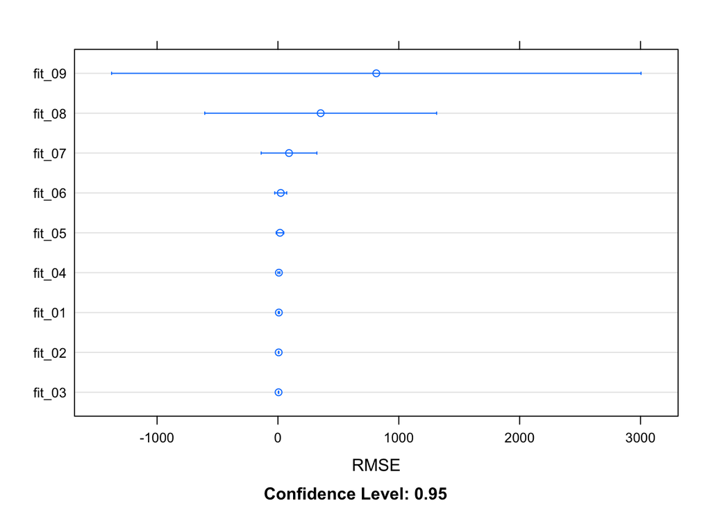

```r
### dotplot for your performance metric
dotplot(lowhigh_results, metric = "RMSE")
```

Which model is the best?

**The fit_3 model is the best.Because it’s RMSE value is the lowest.**

### 4f)

The `mod_lowhigh_*` variables are `caret` model objects and are essentially lists. Each object, `mod_lowhigh_1` through `mod_lowhigh_9` consists of numerous fields which can be accessed via the dollar sign operator, `$`. One such field, `$finalModel`, provides access to the underlying `lm()` model object associated with the **final fit**. Thus, even though `mod_lowhigh_1` is a `caret` object the field `mod_lowhigh_1$finalModel` is an `lm()` object just like the `fit_lm_1` object you fit at the beginning of the assignment. We can apply functions to help interpret the model behavior just as we did previously.

**You must compare the coefficients between the top 3 models identified by the resampling procedure using the `coefplot::multiplot()` function.**

**Are the coefficient estimates similar for those coefficients present in at least 2 of the models visualized in the previous figure?**

**Is the level or amount of uncertainty associated with the coefficients consistent across the three models?**

#### SOLUTION

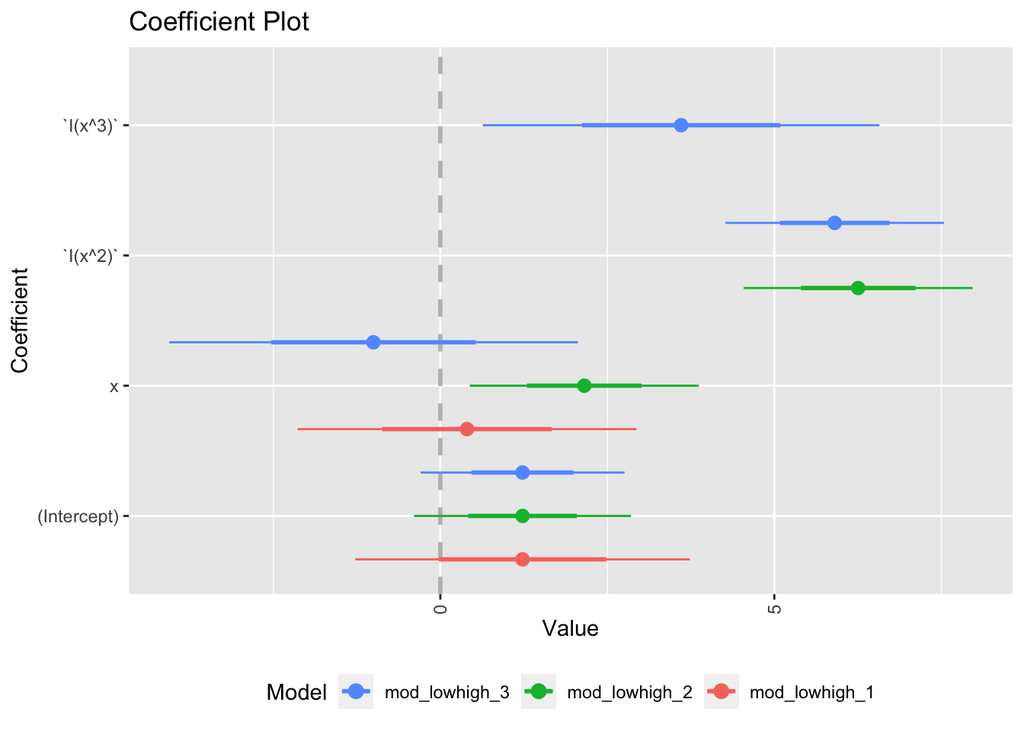

```r
### your code here
coefplot::multiplot(mod_lowhigh_3,mod_lowhigh_2,mod_lowhigh_1)
```

## Problem 05

You have completed an entire regression problem! You correctly used resampling to train and compare simple to complex models in order to identify the most appropriate model that generalizes to new data!

However, let’s try and gain additional insight by repeating the resampling procedure on another data set. The data used in the previous problems were generated using a “high” level of noise. You will now train and compare the same 9 polynomial models, but with data coming from a “low” level of noise. The underlying **data generating process** is the same. All that changed is the noise level. We will learn what that means in more detail throughout this semester. For now, the main purpose is to compare what happens when you can train models under different noise levels.

The low noise level data are loaded in the code chunk below. The glimpse shows that the variable names are the same as those in the high noise level data from before.

```r
path_low_low <- 'hw02_lowsize_lownoise.csv'

df_low_low <- readr::read_csv(path_low_low, col_names = TRUE)
df_low_low %>% glimpse()
```

```
## Rows: 40
## Columns: 2
## $ x <dbl> -0.11464944, 0.22502931, 0.37356406, -2.34241739, 1.15847408, 0.3443…
## $ y <dbl> -1.1796816, -1.1355929, -1.1975801, 8.0392787, 0.7875834, -0.4632007…
```

### 5a)

**Create a scatter plot between the input, `x`, and the response, `y`, for the low noise level data. How does this figure compare to the one you made in Problem 1a)?**

#### SOLUTION

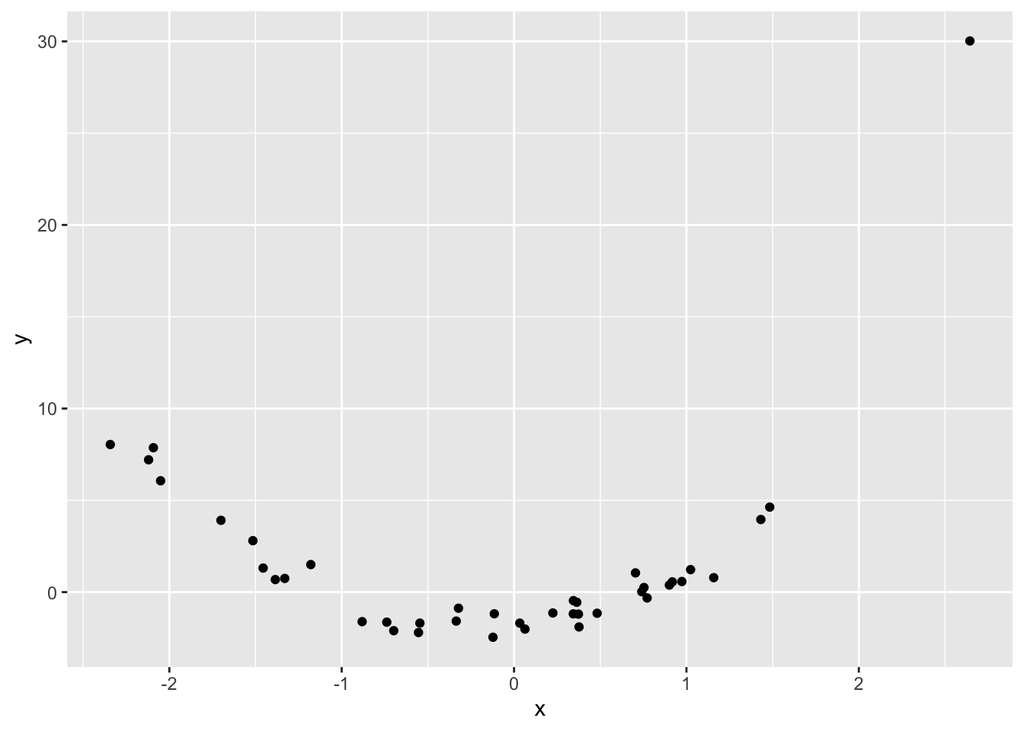

```r
### your code here
df_low_low %>%
  ggplot() +
  geom_point(mapping = aes(x=x,y=y))
```

### 5b)

You will not repeat all of the previous exercises. Instead, you will jump straight to training and evaluating models with resampling. You will use the same resampling scheme and primary performance metric that you used in Problem 04 to train the 9 polynomial models. This time however you will use the low noise level data.

**Train the 9 polynomial models using the required formula interface, `method`, `trControl`, and `metric` arguments that you used in Problem 04. However, pay close attention and set the `data` argument to be `df_low_low`.**

**The variable names and comments specify which polynomial to use.**

*NOTE*: again this is VERY tedious…we will see more efficient ways of going through such a process later in the semester.

#### SOLUTION

```r
### linear relationship (degree 1)
set.seed(2001)
mod_lowlow_1 <- train(y ~ x,
                       data = df_low_low,
                       method = 'lm',
                       metric = my_metric,
                       preProcess = c("center","scale"),
                       trControl = my_ctrl)

mod_lowlow_1
```

```
## Linear Regression
##
## 40 samples
##  1 predictor
##
## Pre-processing: centered (1), scaled (1)
## Resampling: Cross-Validated (5 fold)
## Summary of sample sizes: 32, 32, 32, 32, 32
## Resampling results:
##
##   RMSE      Rsquared   MAE
##   5.144982  0.2415764  3.543544
##
## Tuning parameter 'intercept' was held constant at a value of TRUE
```

```r
### quadratic relationship (degree 2)
set.seed(2001)
mod_lowlow_2 <- train(y ~ x + I(x^2),
                       data = df_low_low,
                       method = 'lm',
                       metric = my_metric,
                       preProcess = c("center","scale"),
                       trControl = my_ctrl)

mod_lowlow_2
```

```
## Linear Regression
##
## 40 samples
##  1 predictor
##
## Pre-processing: centered (2), scaled (2)
## Resampling: Cross-Validated (5 fold)
## Summary of sample sizes: 32, 32, 32, 32, 32
## Resampling results:
##
##   RMSE      Rsquared   MAE
##   2.163325  0.8636634  1.366768
##
## Tuning parameter 'intercept' was held constant at a value of TRUE
```

```r
### cubic relationship (degree 3)
set.seed(2001)
mod_lowlow_3 <- train(y ~ x + I(x^2) + I(x^3),
                       data = df_low_low,
                       method = 'lm',
                       metric = my_metric,
                       preProcess = c("center","scale"),
                       trControl = my_ctrl)

mod_lowlow_3
```

```
## Linear Regression
##
## 40 samples
##  1 predictor
##
## Pre-processing: centered (3), scaled (3)
## Resampling: Cross-Validated (5 fold)
## Summary of sample sizes: 32, 32, 32, 32, 32
## Resampling results:
##
##   RMSE      Rsquared  MAE
##   1.890006  0.90314   1.128333
##
## Tuning parameter 'intercept' was held constant at a value of TRUE
```

```r
### degree 4
set.seed(2001)
mod_lowlow_4 <- train(y ~ x + I(x^2) + I(x^3) + I(x^4),
                       data = df_low_low,
                       method = 'lm',
                       metric = my_metric,
                       preProcess = c("center","scale"),
                       trControl = my_ctrl)

mod_lowlow_4
```

```
## Linear Regression
##
## 40 samples
##  1 predictor
##
## Pre-processing: centered (4), scaled (4)
## Resampling: Cross-Validated (5 fold)
## Summary of sample sizes: 32, 32, 32, 32, 32
## Resampling results:
##
##   RMSE      Rsquared   MAE
##   1.785649  0.9122532  0.9938186
##
## Tuning parameter 'intercept' was held constant at a value of TRUE
```

```r
### degree 5
set.seed(2001)
mod_lowlow_5 <- train(y ~ x + I(x^2) + I(x^3) + I(x^4) + I(x^5),
                       data = df_low_low,
                       method = 'lm',
                       metric = my_metric,
                       preProcess = c("center","scale"),
                       trControl = my_ctrl)

mod_lowlow_5
```

```
## Linear Regression
##
## 40 samples
##  1 predictor
##
## Pre-processing: centered (5), scaled (5)
## Resampling: Cross-Validated (5 fold)
## Summary of sample sizes: 32, 32, 32, 32, 32
## Resampling results:
##
##   RMSE      Rsquared   MAE
##   2.727245  0.9310017  1.327683
##
## Tuning parameter 'intercept' was held constant at a value of TRUE
```

```r
### degree 6
set.seed(2001)
mod_lowlow_6 <- train(y ~ x + I(x^2) + I(x^3) + I(x^4) + I(x^5) + I(x^6),
                       data = df_low_low,
                       method = 'lm',
                       metric = my_metric,
                       preProcess = c("center","scale"),
                       trControl = my_ctrl)

mod_lowlow_6
```

```
## Linear Regression
##
## 40 samples
##  1 predictor
##
## Pre-processing: centered (6), scaled (6)
## Resampling: Cross-Validated (5 fold)
## Summary of sample sizes: 32, 32, 32, 32, 32
## Resampling results:
##
##   RMSE      Rsquared   MAE
##   1.054518  0.9286889  0.6944083
##
## Tuning parameter 'intercept' was held constant at a value of TRUE
```

```r
### degree 7
set.seed(2001)
mod_lowlow_7 <- train(y ~ x + I(x^2) + I(x^3) + I(x^4) + I(x^5) + I(x^6) + I(x^7),
                       data = df_low_low,
                       method = 'lm',
                       metric = my_metric,
                       preProcess = c("center","scale"),
                       trControl = my_ctrl)

mod_lowlow_7
```

```
## Linear Regression
##
## 40 samples
##  1 predictor
##
## Pre-processing: centered (7), scaled (7)
## Resampling: Cross-Validated (5 fold)
## Summary of sample sizes: 32, 32, 32, 32, 32
## Resampling results:
##
##   RMSE      Rsquared   MAE
##   18.33918  0.9102542  6.864169
##
## Tuning parameter 'intercept' was held constant at a value of TRUE
```

```r
### degree 8
set.seed(2001)
mod_lowlow_8 <- train(y ~ x + I(x^2) + I(x^3) + I(x^4) + I(x^5) + I(x^6) + I(x^7) + I(x^8),
                       data = df_low_low,
                       method = 'lm',
                       metric = my_metric,
                       preProcess = c("center","scale"),
                       trControl = my_ctrl)

mod_lowlow_8
```

```
## Linear Regression
##
## 40 samples
##  1 predictor
##
## Pre-processing: centered (8), scaled (8)
## Resampling: Cross-Validated (5 fold)
## Summary of sample sizes: 32, 32, 32, 32, 32
## Resampling results:
##
##   RMSE      Rsquared   MAE
##   47.47409  0.9119027  17.16845
##
## Tuning parameter 'intercept' was held constant at a value of TRUE
```

```r
### degree 9
set.seed(2001)
mod_lowlow_9 <- train(y ~ x + I(x^2) + I(x^3) + I(x^4) + I(x^5) + I(x^6) + I(x^7) + I(x^8) + I(x^9),
                       data = df_low_low,
                       method = 'lm',
                       metric = my_metric,
                       preProcess = c("center","scale"),
                       trControl = my_ctrl)

mod_lowlow_9
```

```
## Linear Regression
##
## 40 samples
##  1 predictor
##
## Pre-processing: centered (9), scaled (9)
## Resampling: Cross-Validated (5 fold)
## Summary of sample sizes: 32, 32, 32, 32, 32
## Resampling results:
##
##   RMSE      Rsquared   MAE
##   71.31048  0.8973848  25.59357
##
## Tuning parameter 'intercept' was held constant at a value of TRUE
```

### 5c)

The code chunk below compiles all of the resampling results together for the models associated with the low noise level data.

```r
lowlow_results = resamples(list(fit_01 = mod_lowlow_1,
                                fit_02 = mod_lowlow_2,
                                fit_03 = mod_lowlow_3,
                                fit_04 = mod_lowlow_4,
                                fit_05 = mod_lowlow_5,
                                fit_06 = mod_lowlow_6,
                                fit_07 = mod_lowlow_7,
                                fit_08 = mod_lowlow_8,
                                fit_09 = mod_lowlow_9))
```

As with the `lowhigh_results` object, you can now visualize summary statistics associated with the resampling results and identify the best performing models.

**You must display the summary table using the `summary()` function for the resampling results and visualize the resampling results using the `dotplot()` function. In both the `summary()` and `dotplot()` functions, you must specify the `metric` argument to be primary performance metric that you specified previously.**

**Which model is the best according to the resampling results?**

#### SOLUTION

```r
### print the resampling summary for the performance metric
summary(lowlow_results,metric = "RMSE")
```

```
##
## Call:
## summary.resamples(object = lowlow_results, metric = "RMSE")
##
## Models: fit_01, fit_02, fit_03, fit_04, fit_05, fit_06, fit_07, fit_08, fit_09
## Number of resamples: 5
##
## RMSE
##             Min.   1st Qu.    Median      Mean   3rd Qu.       Max. NA's
## fit_01 2.4338576 3.6894089 3.7831721  5.144982 4.0641653  11.754307    0
## fit_02 0.7867695 1.2841627 1.7803386  2.163325 1.8969124   5.068442    0
## fit_03 0.8176783 1.0461808 1.1316759  1.890006 1.1782465   5.276249    0
## fit_04 0.7013583 0.8282032 0.9413818  1.785649 1.1272395   5.330062    0
## fit_05 0.5905692 0.5969589 0.7099658  2.727245 0.9455988  10.793134    0
## fit_06 0.5181681 0.6009772 0.6456859  1.054518 0.9478657   2.559893    0
## fit_07 0.5442659 0.6108852 0.9748669 18.339176 1.6140096  87.951850    0
## fit_08 0.5316738 0.6041379 0.9768202 47.474093 1.2175328 234.040298    0
## fit_09 0.5388171 0.5996942 0.9616194 71.310477 4.5202109 349.932044    0
```

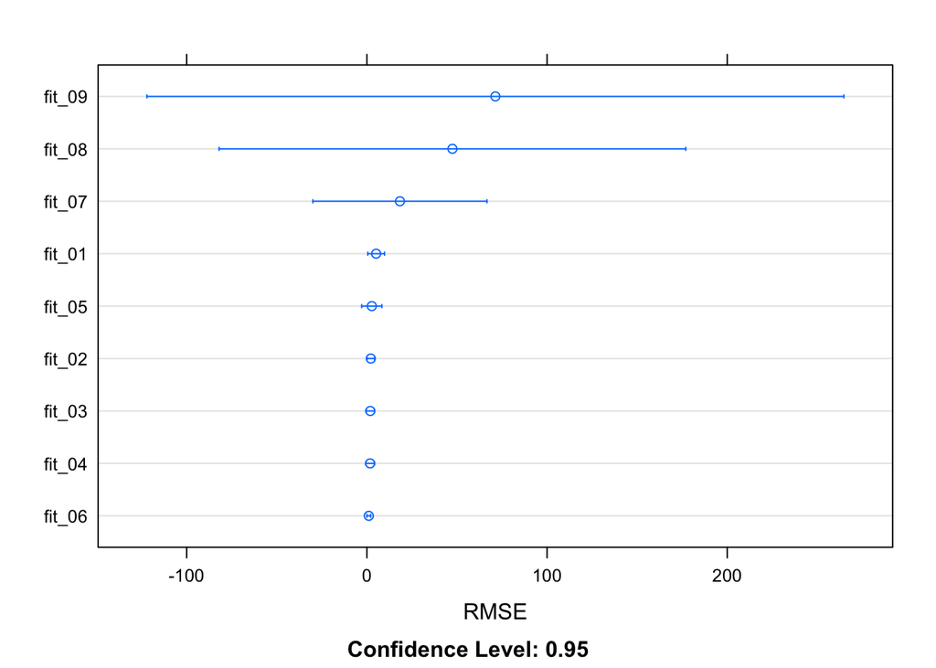

```r
### visualize the dotplot for the performance metric
dotplot(lowlow_results,metric = "RMSE")
```

**Model 6 has the lowest RMSE value, so model 6 is the best**

### 5d)

The `df_low_high` and `df_low_low` data have the same sample size, but the data were generated under different uncontrollable noise levels. This exercise is analogous to recording measurements with worn out low fidelity sensors (`df_low_high`) compared to new modern high resolution sensors (`df_low_low`). The low level of noise gives a “better” glimpse of the real underlying **data generating process**.

**Did the resampling scheme identify the same model as the best model for the two noise cases? Did the models identified to be poor for the high noise case remain poor for the low noise case?**

#### SOLUTION

**The results of low level of noise and high level of noise are not similar. By calculating the RMSE, the final optimal models are not the same. However, the worst models did not perform well in either case. model 4, 3 and 2 performed more consistently, and model 6 performed significantly better after modifying the noise level.**

## Problem 06

You will repeat the resampling exercise with one more data set. This version of the data were generated under the high noise level, as with the first data set you worked with. However, this version of the data has more observations. Thus, you are still working with noisy data, but you now have a higher sample size to work with. This problem therefore focuses on the influence of sample size on the modeling effort.

The high sample size high noise level data are loaded in the code chunk below. The glimpse shows that the variable names are the same as those in the previous two cases.

```r
path_high_high <- 'hw02_highsize_highnoise.csv'

df_high_high <- readr::read_csv(path_high_high, col_names = TRUE)
df_high_high %>% glimpse()
```

```
## Rows: 200
## Columns: 2
## $ x <dbl> -0.11464944, 0.22502931, 0.37356406, -2.34241739, 1.15847408, 0.3443…
## $ y <dbl> -2.56496089, 13.65865394, 0.09488574, 1.51679017, 1.30866543, 1.4072…
```

### 6a)

**Create a scatter plot between the input, `x`, and the response, `y`, for the low noise level data. How does this figure compare to the one you made in Problem 1a)?**

#### SOLUTION

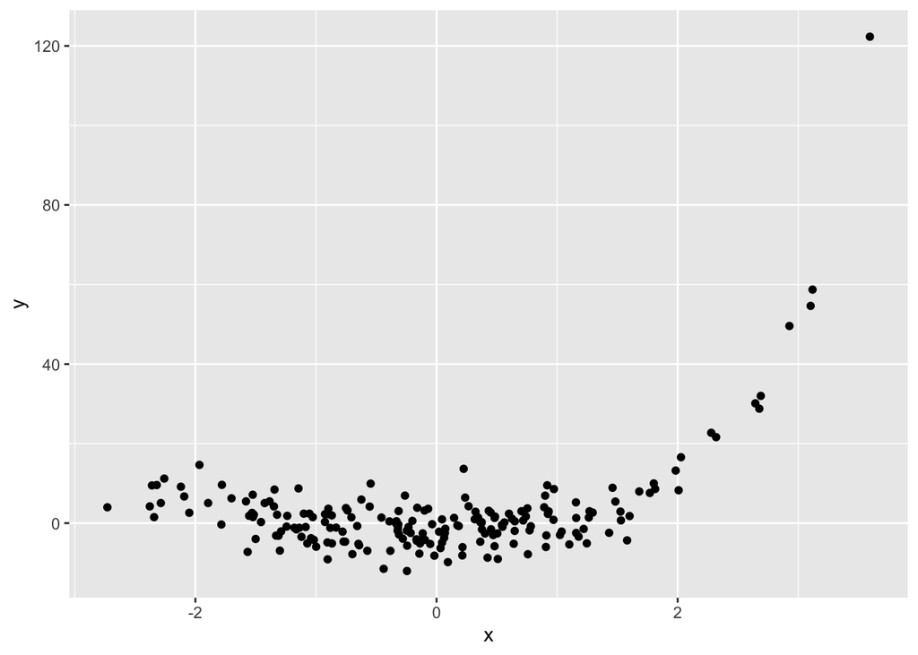

```r
### your code here
df_high_high %>%
  ggplot() +
  geom_point(mapping = aes(x=x,y=y))
```

### 6b)

You must execute resampling on the 9 polynomial models using the high sample size and high noise level data.

**Train the 9 polynomial models using the required formula interface, `method`, `trControl`, and `metric` arguments that you used in Problem 04. However, pay close attention and set the `data` argument to be `df_high_high`.**

**The variable names and comments specify which polynomial to use.**

*NOTE*: again this is VERY tedious…we will see more efficient ways of going through such a process later in the semester.

#### SOLUTION

```r
### linear relationship (degree 1)
set.seed(2001)
mod_highhigh_1 <- train(y ~ x,
                       data = df_high_high,
                       method = 'lm',
                       metric = my_metric,
                       preProcess = c("center","scale"),
                       trControl = my_ctrl)

mod_highhigh_1
```

```
## Linear Regression
##
## 200 samples
##   1 predictor
##
## Pre-processing: centered (1), scaled (1)
## Resampling: Cross-Validated (5 fold)
## Summary of sample sizes: 160, 160, 160, 160, 160
## Resampling results:
##
##   RMSE      Rsquared   MAE
##   10.81521  0.1491076  7.121727
##
## Tuning parameter 'intercept' was held constant at a value of TRUE
```

```r
### quadratic relationship (degree 2)
set.seed(2001)
mod_highhigh_2 <- train(y ~ x + I(x^2),
                       data = df_high_high,
                       method = 'lm',
                       metric = my_metric,
                       preProcess = c("center","scale"),
                       trControl = my_ctrl)

mod_highhigh_2
```

```
## Linear Regression
##
## 200 samples
##   1 predictor
##
## Pre-processing: centered (2), scaled (2)
## Resampling: Cross-Validated (5 fold)
## Summary of sample sizes: 160, 160, 160, 160, 160
## Resampling results:
##
##   RMSE      Rsquared   MAE
##   7.400325  0.6209405  4.934927
##
## Tuning parameter 'intercept' was held constant at a value of TRUE
```

```r
### cubic relationship (degree 3)
set.seed(2001)
mod_highhigh_3 <- train(y ~ x + I(x^2) + I(x^3),
                       data = df_high_high,
                       method = 'lm',
                       metric = my_metric,
                       preProcess = c("center","scale"),
                       trControl = my_ctrl)

mod_highhigh_3
```

```
## Linear Regression
##
## 200 samples
##   1 predictor
##
## Pre-processing: centered (3), scaled (3)
## Resampling: Cross-Validated (5 fold)
## Summary of sample sizes: 160, 160, 160, 160, 160
## Resampling results:
##
##   RMSE      Rsquared   MAE
##   5.811265  0.6668802  4.134066
##
## Tuning parameter 'intercept' was held constant at a value of TRUE
```

```r
### degree 4
set.seed(2001)
mod_highhigh_4 <- train(y ~ x + I(x^2) + I(x^3) + I(x^4),
                       data = df_high_high,
                       method = 'lm',
                       metric = my_metric,
                       preProcess = c("center","scale"),
                       trControl = my_ctrl)

mod_highhigh_4
```

```
## Linear Regression
##
## 200 samples
##   1 predictor
##
## Pre-processing: centered (4), scaled (4)
## Resampling: Cross-Validated (5 fold)
## Summary of sample sizes: 160, 160, 160, 160, 160
## Resampling results:
##
##   RMSE      Rsquared   MAE
##   5.037926  0.6814885  3.769584
##
## Tuning parameter 'intercept' was held constant at a value of TRUE
```

```r
### degree 5
set.seed(2001)
mod_highhigh_5 <- train(y ~ x + I(x^2) + I(x^3) + I(x^4) + I(x^5),
                       data = df_high_high,
                       method = 'lm',
                       metric = my_metric,
                       preProcess = c("center","scale"),
                       trControl = my_ctrl)

mod_highhigh_5
```

```
## Linear Regression
##
## 200 samples
##   1 predictor
##
## Pre-processing: centered (5), scaled (5)
## Resampling: Cross-Validated (5 fold)
## Summary of sample sizes: 160, 160, 160, 160, 160
## Resampling results:
##
##   RMSE     Rsquared   MAE
##   4.33134  0.7031167  3.473011
##
## Tuning parameter 'intercept' was held constant at a value of TRUE
```

```r
### degree 6
set.seed(2001)
mod_highhigh_6 <- train(y ~ x + I(x^2) + I(x^3) + I(x^4) + I(x^5) + I(x^6),
                       data = df_high_high,
                       method = 'lm',
                       metric = my_metric,
                       preProcess = c("center","scale"),
                       trControl = my_ctrl)

mod_highhigh_6
```

```
## Linear Regression
##
## 200 samples
##   1 predictor
##
## Pre-processing: centered (6), scaled (6)
## Resampling: Cross-Validated (5 fold)
## Summary of sample sizes: 160, 160, 160, 160, 160
## Resampling results:
##
##   RMSE      Rsquared   MAE
##   5.028911  0.6920768  3.637877
##
## Tuning parameter 'intercept' was held constant at a value of TRUE
```

```r
### degree 7
set.seed(2001)
mod_highhigh_7 <- train(y ~ x + I(x^2) + I(x^3) + I(x^4) + I(x^5) + I(x^6) + I(x^7),
                       data = df_high_high,
                       method = 'lm',
                       metric = my_metric,
                       preProcess = c("center","scale"),
                       trControl = my_ctrl)

mod_highhigh_7
```

```
## Linear Regression
##
## 200 samples
##   1 predictor
##
## Pre-processing: centered (7), scaled (7)
## Resampling: Cross-Validated (5 fold)
## Summary of sample sizes: 160, 160, 160, 160, 160
## Resampling results:
##
##   RMSE      Rsquared   MAE
##   5.198282  0.6710965  3.686402
##
## Tuning parameter 'intercept' was held constant at a value of TRUE
```

```r
### degree 8
set.seed(2001)
mod_highhigh_8 <- train(y ~ x + I(x^2) + I(x^3) + I(x^4) + I(x^5) + I(x^6) + I(x^7) + I(x^8),
                       data = df_high_high,
                       method = 'lm',
                       metric = my_metric,
                       preProcess = c("center","scale"),
                       trControl = my_ctrl)

mod_highhigh_8
```

```
## Linear Regression
##
## 200 samples
##   1 predictor
##
## Pre-processing: centered (8), scaled (8)
## Resampling: Cross-Validated (5 fold)
## Summary of sample sizes: 160, 160, 160, 160, 160
## Resampling results:
##
##   RMSE      Rsquared   MAE
##   5.986668  0.6932605  3.890623
##
## Tuning parameter 'intercept' was held constant at a value of TRUE
```

```r
### degree 9
set.seed(2001)
mod_highhigh_9 <- train(y ~ x + I(x^2) + I(x^3) + I(x^4) + I(x^5) + I(x^6) + I(x^7) + I(x^8) + I(x^9),
                       data = df_high_high,
                       method = 'lm',
                       metric = my_metric,
                       preProcess = c("center","scale"),
                       trControl = my_ctrl)

mod_highhigh_9
```

```
## Linear Regression
##
## 200 samples
##   1 predictor
##
## Pre-processing: centered (9), scaled (9)
## Resampling: Cross-Validated (5 fold)
## Summary of sample sizes: 160, 160, 160, 160, 160
## Resampling results:
##
##   RMSE      Rsquared  MAE
##   11.74026  0.611759  4.976636
##
## Tuning parameter 'intercept' was held constant at a value of TRUE
```

### 6c)

The code chunk below compiles all of the resampling results together for the models associated with the high sample size and high noise level data.

```r
highhigh_results = resamples(list(fit_01 = mod_highhigh_1,
                                  fit_02 = mod_highhigh_2,
                                  fit_03 = mod_highhigh_3,
                                  fit_04 = mod_highhigh_4,
                                  fit_05 = mod_highhigh_5,
                                  fit_06 = mod_highhigh_6,
                                  fit_07 = mod_highhigh_7,
                                  fit_08 = mod_highhigh_8,
                                  fit_09 = mod_highhigh_9))
```

As with the `lowhigh_results` object, you can now visualize summary statistics associated with the resampling results and identify the best performing models.

**You must display the summary table using the `summary()` function for the resampling results and visualize the resampling results using the `dotplot()` function. In both the `summary()` and `dotplot()` functions, you must specify the `metric` argument to be primary performance metric that you specified previously.**

**Which model is the best according to the resampling results?**

#### SOLUTION

```r
### print the resampling summary for the performance metric
summary(highhigh_results,metric = "RMSE")
```

```
##
## Call:
## summary.resamples(object = highhigh_results, metric = "RMSE")
##
## Models: fit_01, fit_02, fit_03, fit_04, fit_05, fit_06, fit_07, fit_08, fit_09
## Number of resamples: 5
##
## RMSE
##            Min.  1st Qu.   Median      Mean  3rd Qu.      Max. NA's
## fit_01 7.144399 7.709821 8.132484 10.815210 8.953933 22.135414    0
## fit_02 5.190688 5.522222 5.733782  7.400325 6.622219 13.932716    0
## fit_03 4.417490 4.613093 5.121780  5.811265 5.218235  9.685728    0
## fit_04 4.122581 4.595870 4.710784  5.037926 4.925714  6.834681    0
## fit_05 3.930696 4.003262 4.282074  4.331340 4.604970  4.835701    0
## fit_06 3.930049 4.108618 4.618845  5.028911 4.848635  7.638410    0
## fit_07 3.908117 4.535044 4.800166  5.198282 5.311533  7.436552    0
## fit_08 3.897065 4.456369 4.711269  5.986668 4.727407 12.141231    0
## fit_09 3.893277 4.732182 4.751114 11.740260 7.803348 37.521379    0
```

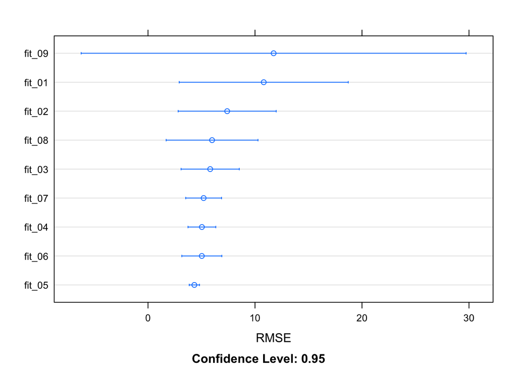

```r
### visualize the dotplot for the performance metric
dotplot(highhigh_results,metric = "RMSE")
```

**Model 5 has the lowest RMSE, so model 5 is the best**

### 6d)

The `df_low_high` and `df_high_high` data have the same noise level, but different sample sizes.

**Did the resampling scheme identify the same model as the best model for the two sample size cases? Did the models identified to be poor for the low sample size case remain poor for the high sample size case?**

#### SOLUTION

**The performance of model 1, model 2 and model 3 was found to be much worse when the sample size was increased again. The models with average performance were optimized after increasing the data size. However, the worst model was still model 9.**

### 6e)

You have executed a model selection task under varying levels of noise and sample sizes. Your goal was to select the best model from a candidate set of varying levels of complexity.

**What do you think the impact is between sample size and noise level on the ability to identify complex behavior?**

#### SOLUTION

**The larger the sample size, it is easier to identify complex behavior. This allows the model to be optimized when it was not performing well in the low sample size case.**

**The low noise level reduces the prediction error of the model and makes the RMSE calculation more accurate. However, it is difficult to determine the performance when using a model that performs well in the low noise level case to fit real data with high uncertainty.**